# Ford-Go-Bike Trip Data

This document explores a dataset containing Ford-Bike Trips and Details OF This Trips for approximately 183,143 Trips.

What is/are the main feature(s) of interest in your dataset?

I'm most interested in figuring out what features are best for comparing With ages and Weekday for all trips.

What features in the dataset do you think will help support your investigation into your feature(s) of interest?

I expect that Age will have the strongest effect on each Trip ..the most days and duration Comparing With Age .

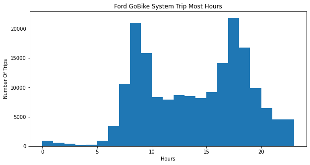

Comparing With Gender For All Trips and discover the big difference for Male especially thursday for (male & Female)

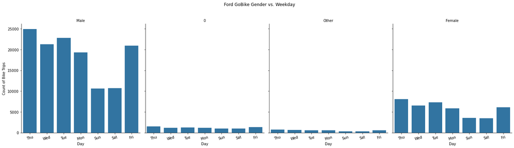

Most Of Users are Male (70%) & Others (female and unknown are 30 %).

Comparing Ages For Riders To (Customers & Subscriber) .

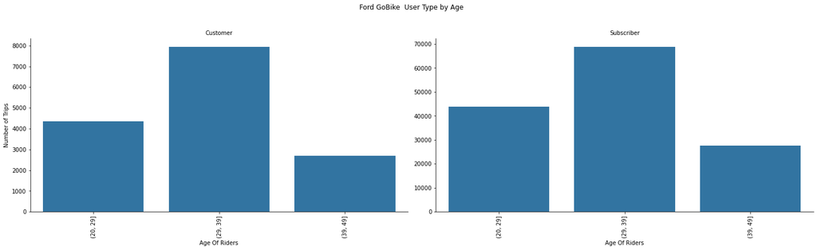

Age Riders Between Customer and Subscriber .. whatever the A big difference Subscriber But The Age is Most for twice is 29:39 and the Least age is 39:49 For Twice

We Here Compare Between Customers With Subscriber and found big different .

Comparing Here With User Type ( Customers & Subscribers ) Of Gender By Duration (by Min).

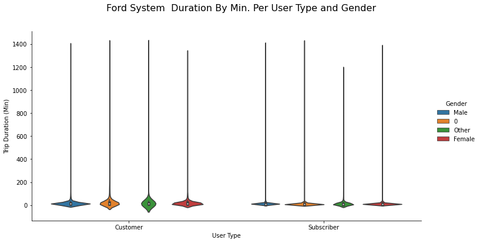

# Talk about some of the relationships you observed in this part of the investigation. Were there features that strengthened each other in terms of looking at your feature(s) of interest?

the previous data of exploration made different visuals and adding in more variables comparing with other variable